# **Logistic regression**

## Summary

- Prior to starting the **“*RStudio Exercise 3*”** I have completed the DataCamp excerise **“Logistic regression”**, wherein functionalities such as handling data (combining, mutating, selecting, filtering) were well understood. Apart from exploring, fitting and predicting using logistic regression models, I have also familiarized with apporaches to model validation.
- The analysis dataset for the **“*RStudio Exercise 3*”** was generated following the **Data Wrangling** protocol where in a dataframe *alc* data was processed such that it contains 382 rows and 35 variables.

## Procedure for Exercise 3

### Libraries:

```r
library(dplyr)
```

```r
library(tidyr)
library(ggplot2)
library(boot)
```

### Reading the data:

```r
alc <- read.table('data/alc_data.txt', header=TRUE)
glimpse(alc)
```

```
## Observations: 382
## Variables: 35
## $ school     <fctr> GP, GP, GP, GP, GP, GP, GP, GP, GP, GP, GP, GP, GP...
## $ sex        <fctr> F, F, F, F, F, M, M, F, M, M, F, F, M, M, M, F, F,...
## $ age        <int> 18, 17, 15, 15, 16, 16, 16, 17, 15, 15, 15, 15, 15,...
## $ address    <fctr> U, U, U, U, U, U, U, U, U, U, U, U, U, U, U, U, U,...
## $ famsize    <fctr> GT3, GT3, LE3, GT3, GT3, LE3, LE3, GT3, LE3, GT3, ...
## $ Pstatus    <fctr> A, T, T, T, T, T, T, A, A, T, T, T, T, T, A, T, T,...
## $ Medu       <int> 4, 1, 1, 4, 3, 4, 2, 4, 3, 3, 4, 2, 4, 4, 2, 4, 4, ...
## $ Fedu       <int> 4, 1, 1, 2, 3, 3, 2, 4, 2, 4, 4, 1, 4, 3, 2, 4, 4, ...
## $ Mjob       <fctr> at_home, at_home, at_home, health, other, services...
## $ Fjob       <fctr> teacher, other, other, services, other, other, oth...
## $ reason     <fctr> course, course, other, home, home, reputation, hom...
## $ nursery    <fctr> yes, no, yes, yes, yes, yes, yes, yes, yes, yes, y...
## $ internet   <fctr> no, yes, yes, yes, no, yes, yes, no, yes, yes, yes...
```

[output cut: 22 more lines]

```r
colnames(alc)
```

```
##  [1] "school"     "sex"        "age"        "address"    "famsize"
##  [6] "Pstatus"    "Medu"       "Fedu"       "Mjob"       "Fjob"
## [11] "reason"     "nursery"    "internet"   "guardian"   "traveltime"
## [16] "studytime"  "failures"   "schoolsup"  "famsup"     "paid"
## [21] "activities" "higher"     "romantic"   "famrel"     "freetime"
## [26] "goout"      "Dalc"       "Walc"       "health"     "absences"
## [31] "G1"         "G2"         "G3"         "alc_use"    "high_use"
```

#### Exploring the data:

- The data is obtained from a series of questionaries from two Portuguese Schools with 382 students with 33 varibales (2 variables are added later).
- The preformace of students in two subjects Maths and Portuguese are provided.
- The dataset contains attributes such as **age, sex, family size, internet, romantic, paid and other binary variable** shown through the *glimpse* function, the continous varibles are **grades secured by the students in three different periods along with alcohol consumptions workday/weekday**.
- The alcohol consumptions were further categorized as **high/low consumptions** such that the avergae alcohol consumptions workday/weekday is **greater than 2**.

#### Data Analysis:

```r
my_var <- c("famsize" , "romantic", "freetime","goout")
my_model <- glm(high_use ~ famsize + romantic + freetime + goout, data = alc, family = "binomial")
```

##### Variable hypothesis:

- Family size (**famsize**) I hypothesize that students in a bigger family size will be prone to drink more.
- The romantic relationship (**romantic**) status yes/no, of the students might have an influence on the degree of alcohol consumptions, as I hypothesize that student would are in a romantic relationship would be porne to drink more.
- Free-time (**freetime**) varibale would have an underlying effcet on alcohol consumptions, as I hypothesize that students with more freetime would be prone to high level of alcohol consumption.
- Going-out (**goout**) varaible determines the friends cricle of students and I hypothesize that students how go-out more would be prone to high level of alcohol consumption.

#### Numerical and Graphical exploration the data:

```r
alc_data <- select(alc, one_of(c(my_var,"high_use")))
summary(alc_data)
```

```
##  famsize   romantic     freetime        goout        high_use
##  GT3:278   no :261   Min.   :1.00   Min.   :1.000   Mode :logical
##  LE3:104   yes:121   1st Qu.:3.00   1st Qu.:2.000   FALSE:268
##                      Median :3.00   Median :3.000   TRUE :114
##                      Mean   :3.22   Mean   :3.113
##                      3rd Qu.:4.00   3rd Qu.:4.000
##                      Max.   :5.00   Max.   :5.000
```

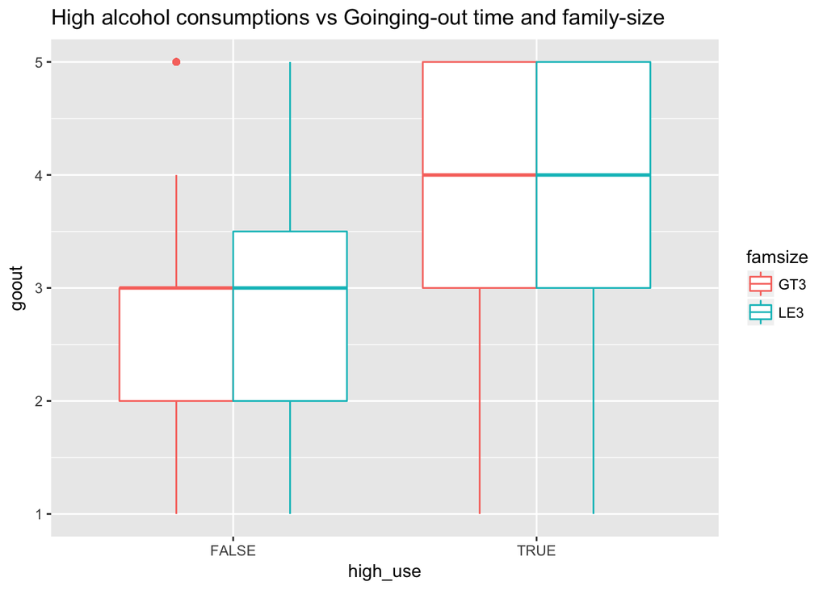

```r
ggplot(alc_data, aes(x = high_use, y = goout, col = famsize)) +geom_boxplot() + ggtitle("High alcohol consumptions vs Goinging-out time and family-size")
```

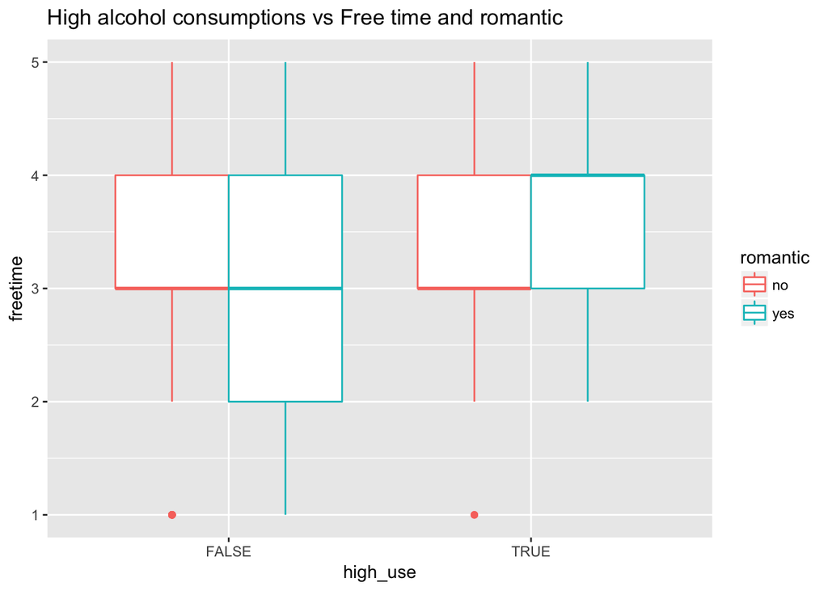

```r
ggplot(alc_data, aes(x = high_use, y = freetime, col = romantic)) + geom_boxplot() + ggtitle("High alcohol consumptions vs Free time and romantic")
```

#### Comments on my hypothesis:

- The explanatory variable going-out (**goout**) with friends, was higher in cases of high alc use whereas the family-size (**famsize**) had no effect of the high alc use.
- Similary the varibale free-time (**freetime**) by iteslf had no effect on the high alc use, but students in a romantic relationship (**romantic**) had higher free time and were porne to high alc use.

#### Logistic regression:

```r
log_model <- glm(high_use ~ famsize + romantic + freetime + goout, data = alc_data, family = "binomial")
summary(log_model)
```

```
##
## Call:
## glm(formula = high_use ~ famsize + romantic + freetime + goout,
##     family = "binomial", data = alc_data)
##
## Deviance Residuals:
##     Min       1Q   Median       3Q      Max
## -1.5554  -0.7900  -0.5379   0.9899   2.4649
##
## Coefficients:
##             Estimate Std. Error z value Pr(>|z|)
## (Intercept)  -3.7135     0.5393  -6.885 5.76e-12 ***
## famsizeLE3    0.3968     0.2641   1.502    0.133
## romanticyes  -0.2638     0.2644  -0.998    0.318
## freetime      0.1286     0.1319   0.975    0.330
## goout         0.7315     0.1204   6.075 1.24e-09 ***
## ---
## Signif. codes:  0 '***' 0.001 '**' 0.01 '*' 0.05 '.' 0.1 ' ' 1
##
## (Dispersion parameter for binomial family taken to be 1)
##
##     Null deviance: 465.68  on 381  degrees of freedom
## Residual deviance: 411.63  on 377  degrees of freedom
## AIC: 421.63
##
## Number of Fisher Scoring iterations: 4
```

```r
OR <- coef(log_model) %>% exp
CI <- confint(log_model) %>% exp
cbind(OR,CI)
```

```
##                     OR       2.5 %     97.5 %
## (Intercept) 0.02439252 0.008158479 0.06787269
## famsizeLE3  1.48704676 0.882770026 2.49225699
## romanticyes 0.76810291 0.453342164 1.28131049
## freetime    1.13718714 0.878467903 1.47520308
## goout       2.07829869 1.651370444 2.65038452
```

#### Interpret the results:

- From the summary of the model the explanatory variables that was evident in explaining the high alcohol consumption was the **goout** variables which along with the intercept had a higher lievel of significance shown through the P-values.
- Based on my hypothesis all the other variables expect **goout** failed to explain the high alc use.
- Based on the exponents of the coefficients values of the models i.e, **Odds Ratio** It was possible to ascertain that variables **(famsize (less than 3), freetime and goout)** having OR’s > 1 are positively asscoiated to successfuly association with high alc use, whereas **romantic** relationship presence was not sufficient to explain the high alc use.
- The variables **(famsize and romantic)** are factor variables shown through the str(alc_data) command. For these variables the coef values are intrepretted as their difference from the intercept.
- Through the CI caluctaion it can be found that the OR’s at 95% confidence (2.5% left tail and 97.5% right tail), we can be say the such OR values of the our explanatory variables in the model has 95% probability to fall between the ranges given in the columns **(2.5 & 97.5)**

#### Model predictions:

```r
log_model2 <- glm(high_use ~ goout, data = alc_data, family = "binomial")
probabilities <- predict(log_model2, type = "response")
alc_data <- mutate(alc_data, probability = probabilities)
alc_data <- mutate(alc_data, prediction = probability > 0.5)
table(high_use = alc_data$high_use, prediction = alc_data$prediction)
```

```
##         prediction
## high_use FALSE TRUE
##    FALSE   247   21
##    TRUE     82   32
```

```r
loss_func <- function(class, prob) {
  n_wrong <- abs(class - prob) > 0.5
  mean(n_wrong)
}
loss_func(class = alc_data$high_use, prob = alc_data$probability)
```

```
## [1] 0.2696335
```

```r
log_model3 <- glm(high_use ~ freetime, data = alc_data, family = "binomial")
probabilities <- predict(log_model3, type = "response")
alc_data <- mutate(alc_data, probability = probabilities)
alc_data <- mutate(alc_data, prediction = probability > 0.5)
table(high_use = alc_data$high_use, prediction = alc_data$prediction)
```

```
##         prediction
## high_use FALSE
##    FALSE   268
##    TRUE    114
```

```r
loss_func <- function(class, prob) {
  n_wrong <- abs(class - prob) > 0.5
  mean(n_wrong)
}
loss_func(class = alc_data$high_use, prob = alc_data$probability)
```

```
## [1] 0.2984293
```

#### Cross-validation (Bonus):

```r
cv <- cv.glm(data = alc_data, cost = loss_func, glmfit = log_model2, K = 10)
cv$delta[1]
```

```
## [1] 0.2696335
```

#### Comments:

- The model after 10 fold Cross-validation has a similar penalty as log_model2 and their loss penalities were 0.26.
- Yes, using the **goout** variable the I was able to find a similar model.

#### Cross-validation (Different logistic models-Super bonus):

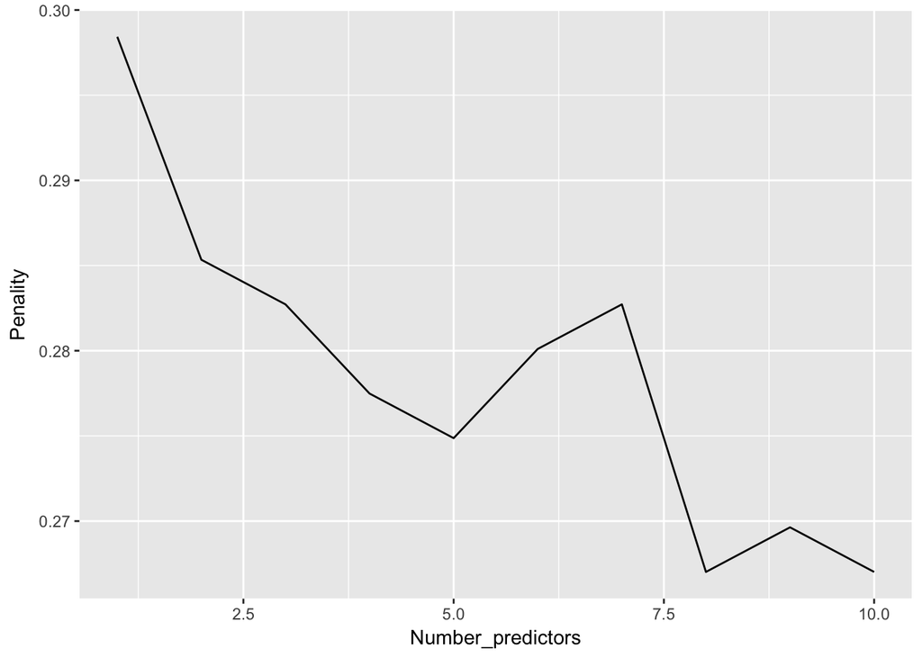

```r
get_log_model <- function(mydata){
  mymod <- glm(high_use ~ ., data = mydata, family = "binomial")
  cv <- cv.glm(data = mydata, cost = loss_func, glmfit = mymod, K = 10)
  return(cv$delta[1])
}

cv_values <- c()
cnames <- c("famrel", "internet", "age", "paid", "school", "Pstatus", "famsup", "romantic", "absences", "address")
predictors <- cnames
for( i in length(predictors):1){
    tempdata <- select(alc, one_of(c(predictors[i:length(predictors)],"high_use")))
    cv_values[i] <- get_log_model(tempdata)
}

results <- as.data.frame(cbind(Number_predictors = 10:1, Penality = cv_values))
ggplot(results, aes(x = Number_predictors, y = Penality))+geom_line()
```

#### Comments:

- As the number of predictors in the model were decreased (10 to 1) the penality of the model were found to be increasing.
- An inverse relationship was found between the number of predictors and the error after 10 fold cross-validation.